# Lab 1 - Nossas Perguntas

Gabriel Morais Lúcio de Araújo

23 de abril de 2018

```r
dados = read_csv(here("data/series_from_imdb.csv"),
                    progress = FALSE,
                    col_types = cols(.default = col_double(),
                                     series_name = col_character(),
                                     episode = col_character(),
                                     url = col_character(),
                                     season = col_character())) %>% filter(series_name %in% c("Black Mirror", "Mr Robot"))

series <- dados %>% group_by(series_name) %>%
  summarise(n = n())
```

#### Qual das séries que você escolheu é mais bem avaliada no IMDB? A diferença é grande? Pequena? Muda de acordo com as temporadas da série?

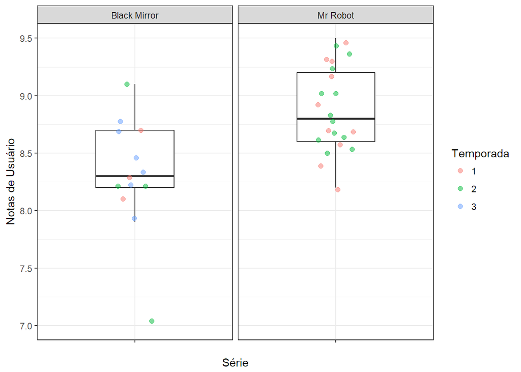

```r
boxplot.user_ratings <- dados %>%
  ggplot(aes(x = "", y = user_rating)) +
  geom_boxplot(width = .4, outlier.color = NA) +
  facet_wrap(~ series_name) +
  geom_jitter(width = .1, size = 2, alpha = .5, aes(color = season)) +
  labs('Série mais bem avaliada IMDB', x = 'Série', y = 'Notas de Usuário', color = 'Temporada')

boxplot.user_ratings
```

Considero a série mais bem avaliada como sendo a com maior mediana. Então temos a série *Black Mirror* com mediana = **8.3** e a série *Mr Robot* com mediana = **8.8**. A diferença não é grande, chegando a maior diferença de **0.6** entre a mediana da 2ª temporada de ambas as séries. Algo interessante é que na 2 temporada de *Black Mirror* temos tanto o episódio mais bem avaliado quanto o episódio pior avaliado, sendo o episódio *White Christmas* com nota **9.1** e o eposódio *The Waldo Moment* com nota **7.0**.

#### Qual das séries que você escolheu tem episódios de qualidade mais irregular segundo o IMDB? A diferença é grande? Pequena?

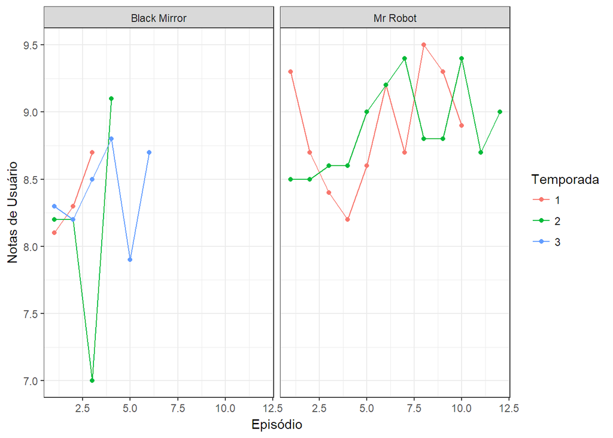

```r
line.user_ratings <- dados %>%
  ggplot(aes(x = season_ep, y = user_rating, color = season, group = season)) +
  geom_line() +
  geom_point() +
  facet_wrap(~ series_name) +
  labs('Série mais bem avaliada IMDB', x = 'Episódio', y = 'Notas de Usuário', color = 'Temporada')

line.user_ratings
```

Podemos ver que *Mr Robot* não possui uma variação muito notável nas notas de seus episódios, já em *Black Mirror* é possível notar que a 2ª e 3ª temporada possuem um episódio, em cada, que tem uma qualidade bem mais inferior que o restante dos episódios. Inclusive, temos na 2ª temporada o episódio pior avaliado e em seguida temos o melhor avaliado da série, com uma diferença de aproximadamente **2.0**(*The Waldo Moment* tem uma nota 22% menor que a nota do episódio *White Christmas*.

Assim, *Black Mirror* tem uma qualidade mais irregular de episódios. Como assisto a série, posso dizer que isso se aplica devido ao fato que os episódios da série são independentes, ou seja, cada um tem a sua história com ínicio, meio e fim. Assim alguns roteiros se destacam muito mais em relação a outros, nem sempre a série consegue manter um nível muito alto, como em **White Christmas** (meu episódio favorito da série).

### Extras

#### Qual das séries ou temporadas tem episódios mais sem graça? (Um episódio é sem graça se ninguém nem ama nem odeia ele)

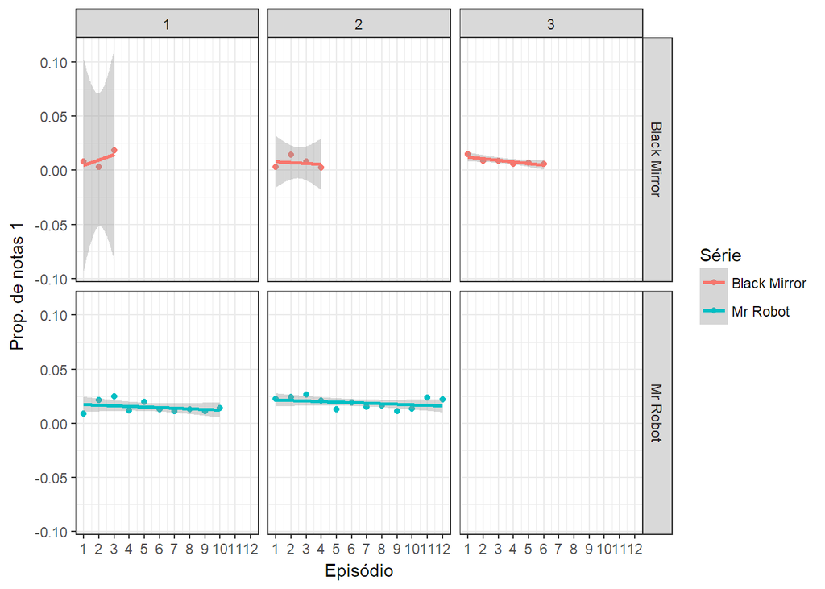

```r
odiado.r1 <- dados %>%
  ggplot(aes(x = season_ep, y = r1, color = series_name)) +
  geom_point() +
  geom_smooth(method = lm) +
  facet_grid(series_name ~ season) +
  scale_x_continuous(breaks = 1:12) +
  labs('Episódio mais odiado', x = 'Episódio', y = 'Prop. de notas 1', color = 'Série')

odiado.r1
```

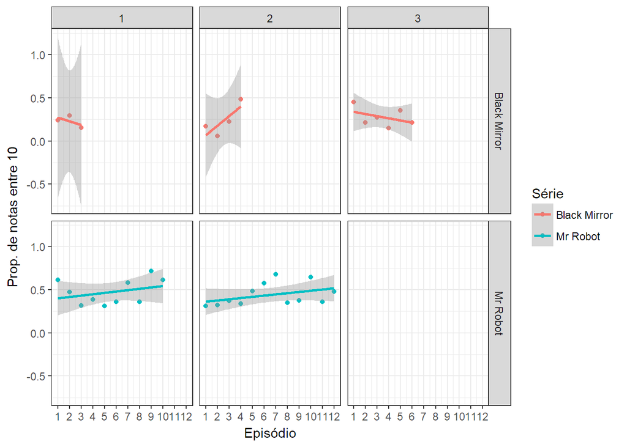

```r
amado.r10 <- dados %>%
  ggplot(aes(x = season_ep, y = r10, color = series_name)) +
  geom_point() +
  geom_smooth(method = lm) +
  facet_grid(series_name ~ season) +
  scale_x_continuous(breaks = 1:12) +
  labs('Episódio mais amado', x = 'Episódio', y = 'Prop. de notas entre 10', color = 'Série')

amado.r10
```

Podemos ver os como se comportam a proporções de episódios mais amados e mais odiados nas séries. *Mr Robot* tem uma correlação muito baixa, os episódios da série tendem a manter um nível que agrada os fãs de forma geral. Diferente de *Black Mirror* que tem uma variação maior, porém possui menos episódios para uma melhor análise.

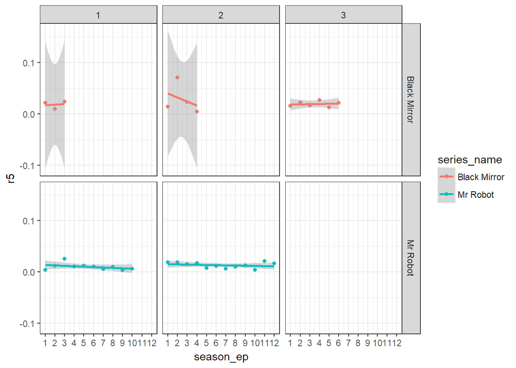

```r
meh.r5 <- dados %>%
  ggplot(aes(x = season_ep, y = r5, color = series_name)) +
  geom_point() +
  geom_smooth(method = lm) +
  facet_grid(series_name ~ season) +
  scale_x_continuous(breaks = 1:12)

meh.r5
```

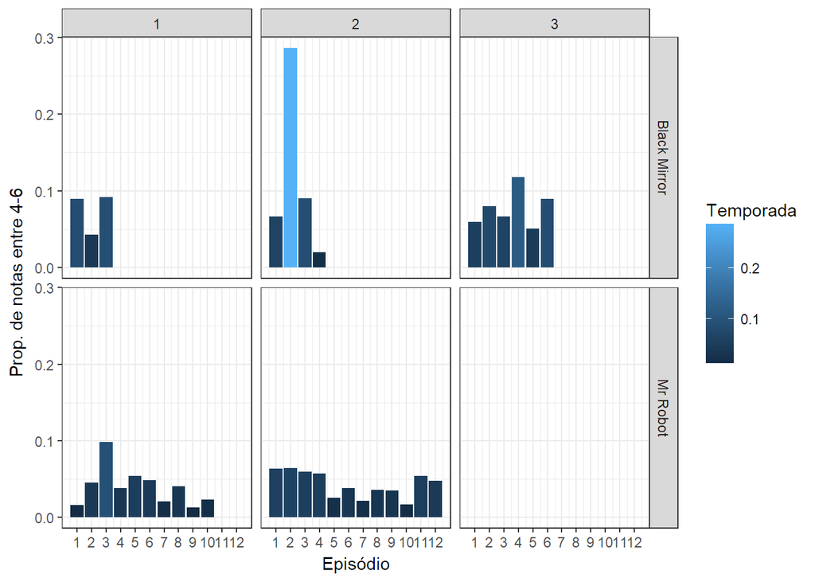

```r
dados <- dados %>% mutate(meh = r4 + r5 + r6) # meh = soma das proporções entre r4, r5 e r6

meh.bar <- dados %>%
  ggplot(aes(x = season_ep, y = meh, fill = meh)) +
  geom_bar(stat="identity") +
  facet_grid(series_name ~ season) +
  scale_x_continuous(breaks = 1:12) +
  labs('Episódio mais sem graça', x = 'Episódio', y = 'Prop. de notas entre 4-6', fill = 'Temporada')

meh.bar
```

Condiderei um episódio sem graça (*meh*) aquele que possui a maior proporção de notas entre 4 e 6. Descobrimos aqui que o 2° episódio da 2ª temporada de *Black Mirror* é o episódio mais sem graça das duas séries. Foi algo inexperado para mim, pensei que o episódio pior avaliado (o 3º episódio da 2ª temporada) teria uma proporção de ‘meh’ maior do que os outros, porém a proporção de ‘meh’ dele está bem parecida com a de outros episódios. Por outro lado temos o episódio mais bem avaliado de *Black Mirror* com menor ‘meh’ da série.

#### Episódios no início/fim da temporada são mais bem avaliados que os no meio? O que tende a ser melhor? Inícios ou finais de séries/temporadas?

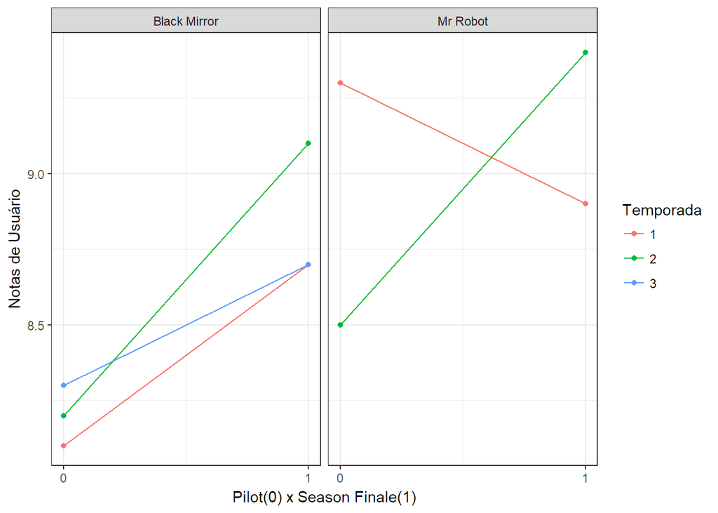

```r
inicio.geral <- dados %>%
    group_by(series_name) %>%
    filter(season_ep == 1)
inicio.geral$tipo <- rep(0,nrow(inicio.geral))

fim.mrrobot.1 <- dados %>%
    filter(season_ep == 10, season == 1, series_name == 'Mr Robot')
fim.mrrobot.2 <- dados %>%
    filter(season_ep == 10, season == 2, series_name == 'Mr Robot')

fim.blackmirror.1 <- dados %>%
    filter(season_ep == 3, season == 1, series_name == 'Black Mirror')
fim.blackmirror.2 <- dados %>%
    filter(season_ep == 4, season == 2, series_name == 'Black Mirror')
fim.blackmirror.3 <- dados %>%
    filter(season_ep == 6, season == 3, series_name == 'Black Mirror')

fim.geral <- rbind(fim.blackmirror.1, fim.blackmirror.2, fim.blackmirror.3, fim.mrrobot.1, fim.mrrobot.2)
fim.geral$tipo <- rep(1,nrow(fim.geral))

dados.inicio.fim <- rbind.data.frame(inicio.geral, fim.geral)

dados.ggplot <- dados.inicio.fim %>%
    ggplot(aes(x = tipo, y = user_rating, color = season)) +
    geom_line() +
    geom_point() +
    facet_wrap(~ series_name) +
    scale_x_continuous(breaks = 0:1) +
    labs('Pilot x Season Finale', x = 'Pilot(0) x Season Finale(1)', y = 'Notas de Usuário', color = 'Temporada')

dados.ggplot
```

Na série *Black Mirror* o início da temporada tende a ser pior que o final da temporada. Já para *Mr Robot* temos que a primeira temporada tem um início melhor que o seu final.